# Assignment2

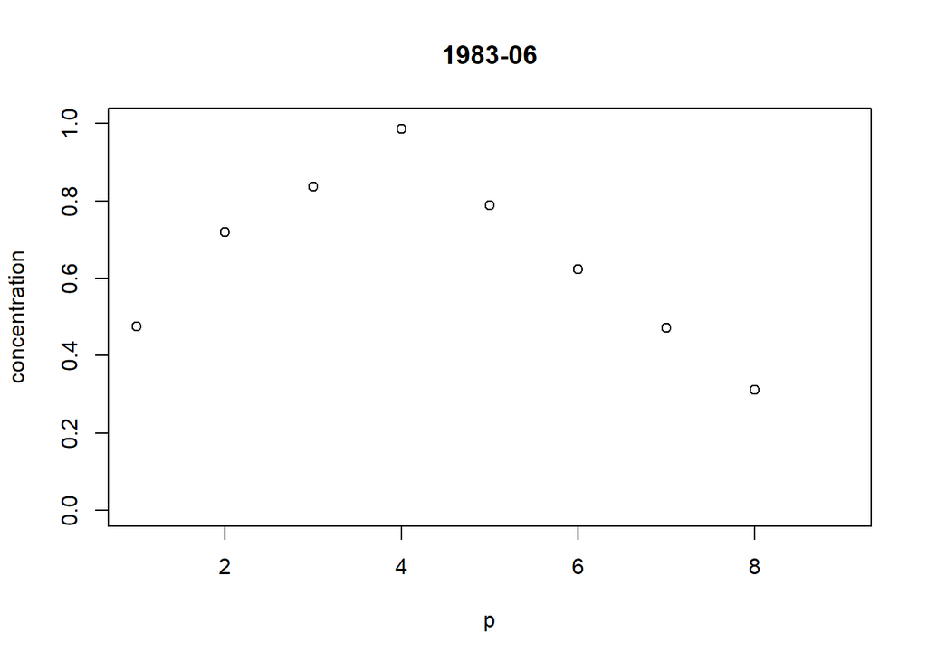

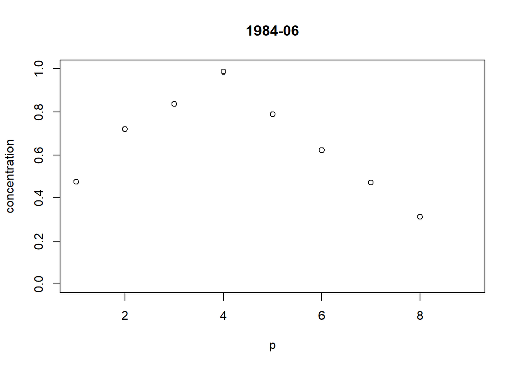

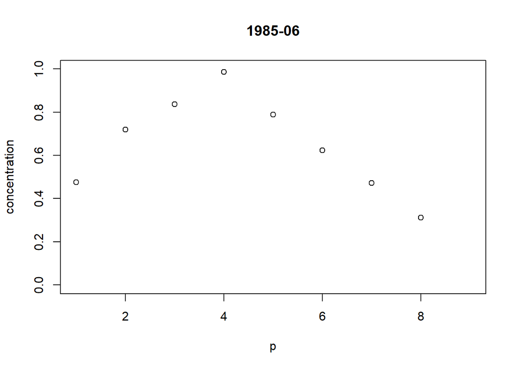

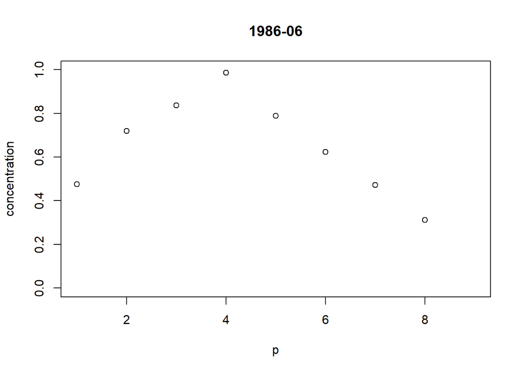

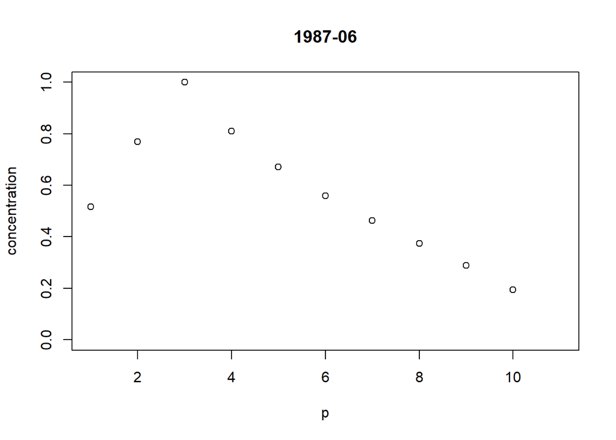

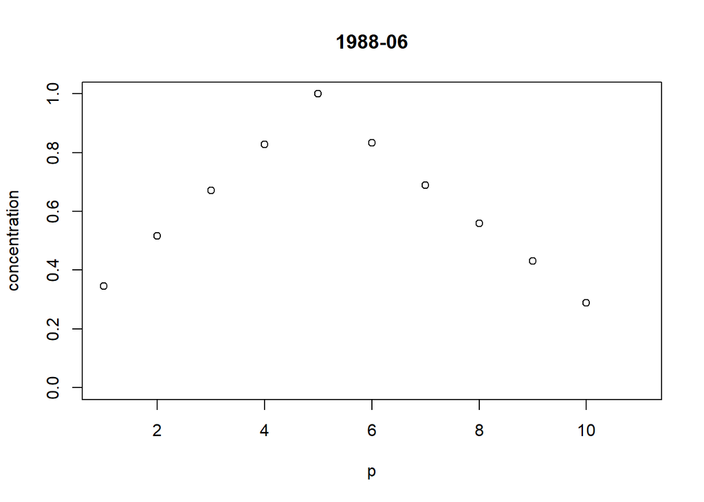

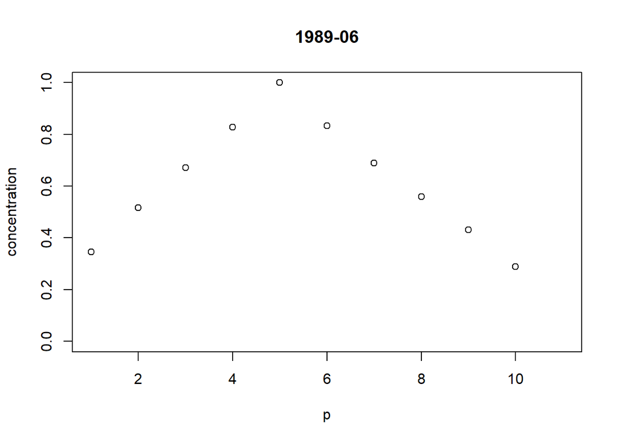

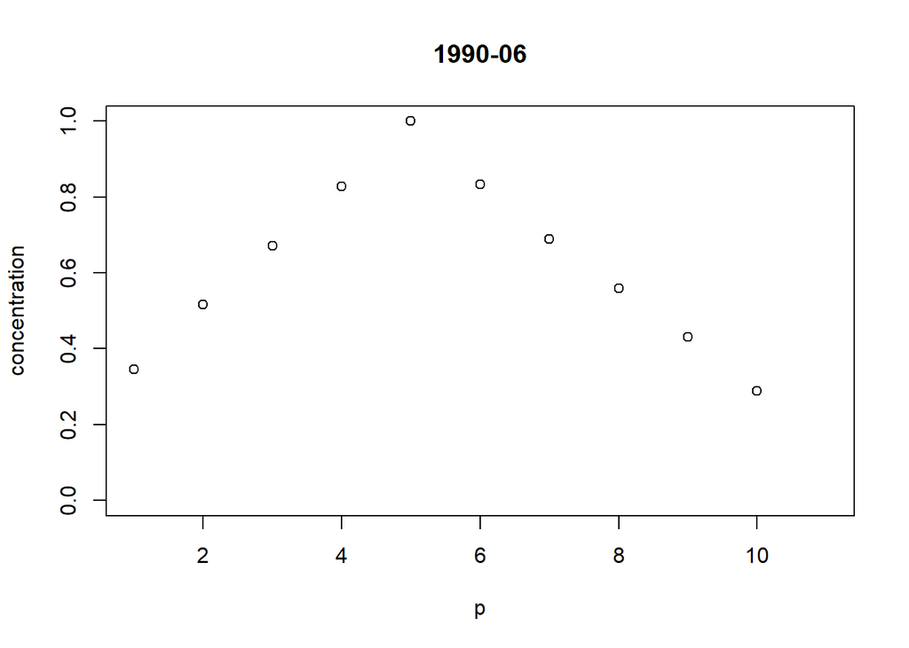

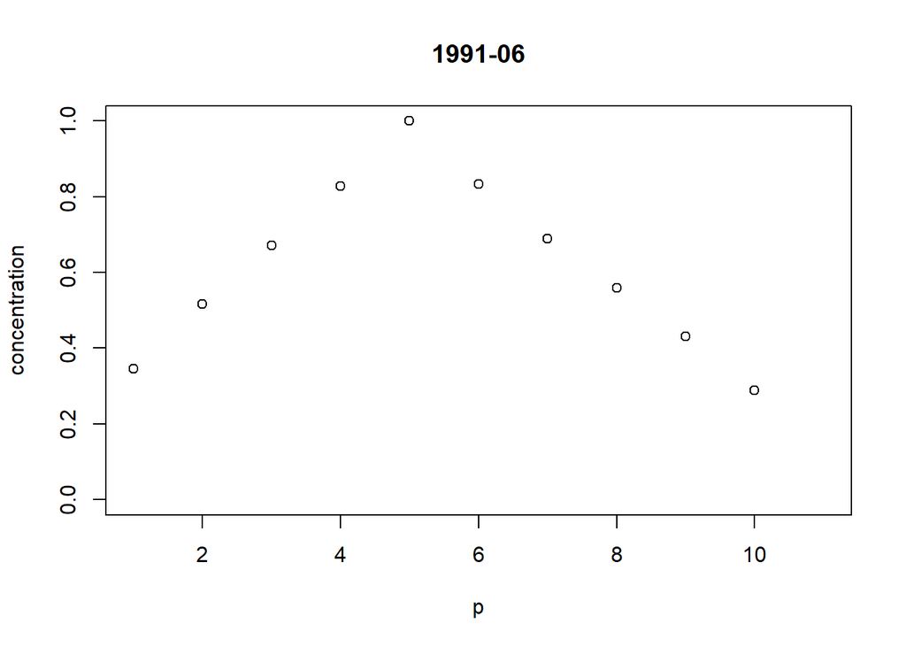

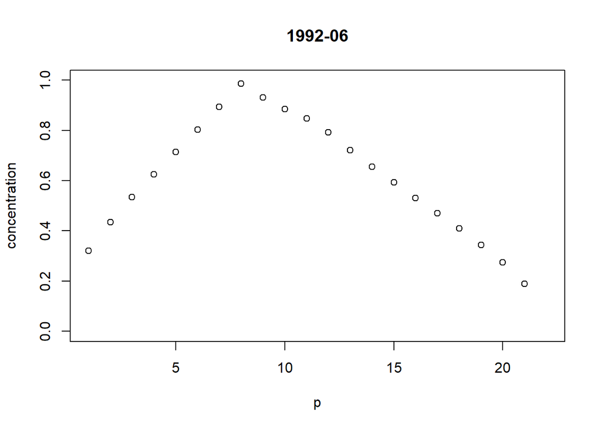

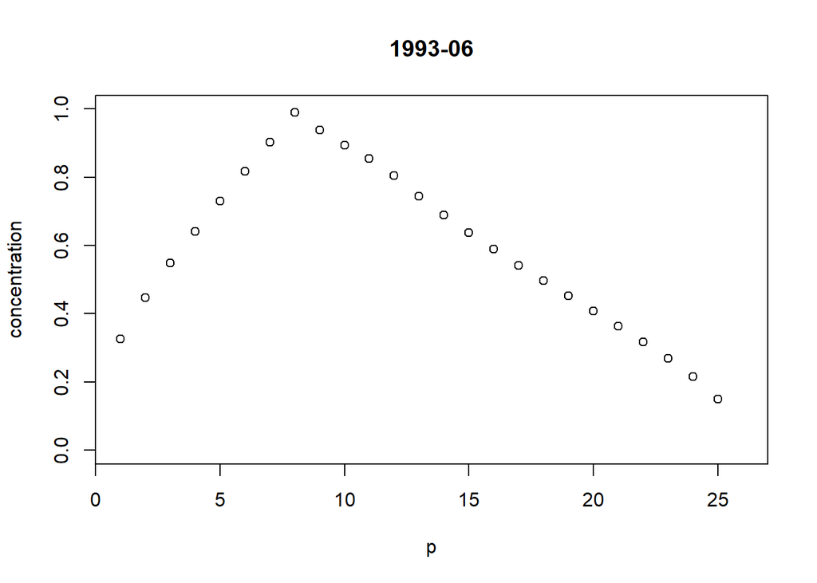

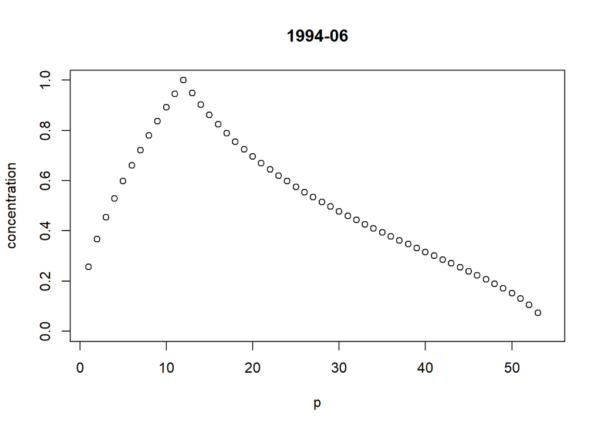

[20 more figures not shown]

```r
#using basically the function above, but altered, to print out graphs for every month across years (e.g. all Januarys acros all years)
suppressWarnings(for(i in 1:32){
  NetworkDecay = graph_from_edgelist(ELStorage[[(12+12*i)]], directed = FALSE)
  c <- eigen_centrality(NetworkDecay)$vector
  c[c>0.99] <- 1
  c[c<0.01] <- 0
  c_cal <- c
  concentration <- c()
  cp <- rep(0,length(c))
  for(j in 1:length(c)){
    index <- which.max(c_cal)
    c_cal[index] <- -1
    cp[index] <- 1
    new_concentration <- cor(c, cp)
    concentration <- append(concentration, new_concentration)
  }
  #plot the graphs
  plot(1:length(c), concentration, main = paste(i+1982,"-06",sep=""),xlab = "p",ylim = c(0,1))
})
```

2. Do you think that the recent network now exhibits more of a core-periphery structure or a structure made up of distinctly clustered components? Provide two other pieces of descriptive evidence outside of the conentration scores to support your conclusion.

```r
#Method 1: Looking at betweeness
between <- betweenness(NtwkClean, v = V(NtwkClean), directed = FALSE, normalized = TRUE)
print("mean between")
```

```
## [1] "mean between"
```

```r
mean(between)
```

```
## [1] 0.0001759037
```

```r
print("max between")
```

```
## [1] "max between"
```

```r
max(between)
```

```
## [1] 0.07807952
```

```r
# The average betweeness of the ntework is extremely small, with the max at only 0.08. This means that the nodes on average have very low brokerage and bridging characteristics. With the nodes having very similar information, it is vastly more likely that the network is core-preiphery than clustered components.
```

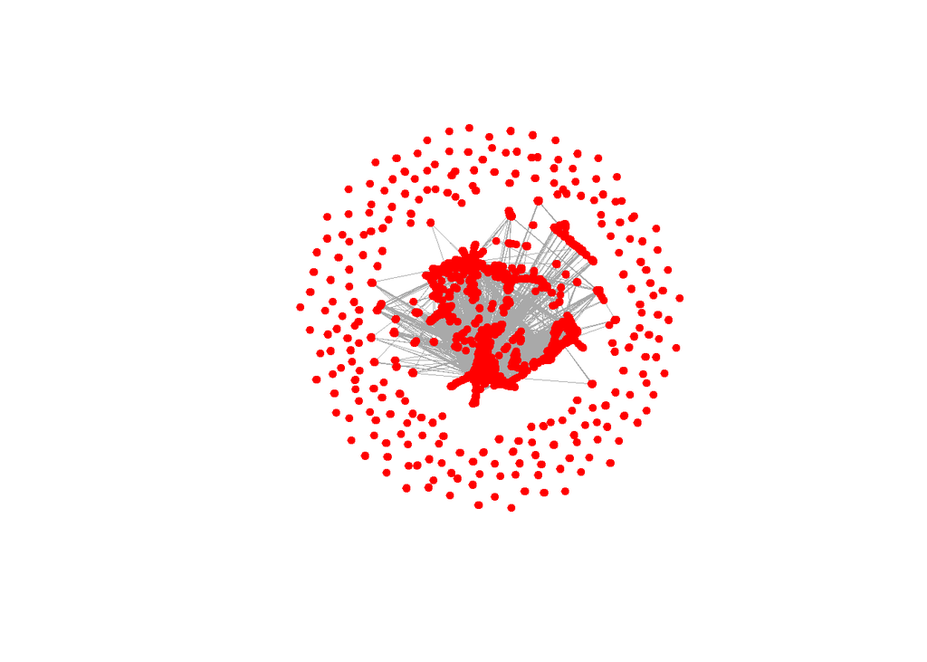

```r
#Method 2: Plotting the network and visually inspect it
plot(NtwkClean, vertex.label=NA, vertex.color = "Red", vertex.frame.color="Red", vertex.size = 4, edge.width = 0.05)
```

```r
#Looking at the graph, it is clear that the network is very core-periphery, with one large central core and not any distintive clustered components
```

Question 4

4. Last, we will analyze whether being in the core, being at the center of the network, and being a member of a densely connected group helps venture capital firms and the entrepreneurs they work with to perform better. You may use whichever statistical approach you wish to determine the direction and strength of the relationship between network position and a venture capital firm’s performance.
1. Is a venture capital firm being in the core, being at the center of the network, and being a member of a densely connected group of the network related to having more more successful investments in a given year?

The outcome variable of successful investments is a non-negative integer, so the count family modles can be useful. Some approaches are described at https://cran.r-project.org/web/packages/pscl/vignettes/countreg.pdf.

```r
#Creating empty lists and dataframe for processing
Coreness <- c()
Closeness <- c()
Betweenness <- c()
EigenVector <- c()
DFCoreness <- data.frame()
DFCloseness <- data.frame()
DFBetweenness <- data.frame()
DFEigenVector <- data.frame()

#Making a copy of our whole network
NtwkWhole2 <- NtwkWhole

#Replacing the date of our new network list with just year
for(i in c(1:length(NtwkWhole2[,1]))) {
  NtwkWhole2[i,3] <- year(as.Date(as.numeric(NtwkWhole[i,3])))
}
```

```r
#This huge for loop takes the network and calculates centrality measures, coreness and concentration once everytime a new year is added.
suppressWarnings(for (i in unique(NtwkWhole2[,3])) {
  #This subsets the network into the first year to whatever year the loop is on
  Subset <- NtwkWhole2[1:last(which(NtwkWhole2[,3] == i)),]
  #Creates an edgelist from the subset
  TotalEL <- cbind.data.frame(Subset[,1],Subset[,2])
  #Creates a graph from the edge list
  TotalGraph <- graph.data.frame(TotalEL, directed = FALSE)
  #Calculate Closeness, Betweenness, EigenVector and Coreness of each subset network
  Closeness <- closeness(TotalGraph, vids=V(TotalGraph), mode="all", normalized = TRUE)
  Betweenness <- betweenness(TotalGraph, v = V(TotalGraph), directed = FALSE, normalized = TRUE)
  EigenVector <- eigen_centrality(TotalGraph, directed = FALSE)[["vector"]]
  Coreness <- coreness(TotalGraph)

  #Make a copy of the dataframes of the 4 measures, paste the results of the four measures into their respective lists, and bind the results to their dataframes.
  Copy <- DFCloseness
  DFCloseness <- cbind.data.frame(Closeness,year = i,make.row.names = names(Closeness))
  DFCloseness <- rbind.data.frame(Copy,DFCloseness)
  Copy2 <- DFBetweenness
  DFBetweenness <- cbind.data.frame(Betweenness,year = i,make.row.names = names(Betweenness))
  DFBetweenness <- rbind.data.frame(Copy2,DFBetweenness)
  Copy3 <- DFEigenVector
  DFEigenVector <- cbind.data.frame(EigenVector,year = i,make.row.names = names(EigenVector))
  DFEigenVector <- rbind.data.frame(Copy3,DFEigenVector)
  Copy4 <- DFCoreness
  DFCoreness <- cbind.data.frame(Coreness,year = i,make.row.names = names(Coreness))
  DFCoreness <- rbind.data.frame(Copy4,DFCoreness)
}
)

#Make sure all 4 metrics have the same years
DFBetweenness$year <- DFCloseness$year
DFEigenVector$year <- DFCloseness$year
DFCoreness$year <- DFCloseness$year
```

```r
#Making a copy of the VC performance dataset
VCPerformance <- VC

#Preparing data for inner join, including making sure that the variables are the right type/same type
VCPerformance$year <- as.character(VCPerformance$year)
DFCloseness$make.row.names <- as.character(DFCloseness$make.row.names)
DFBetweenness$make.row.names <- as.character(DFBetweenness$make.row.names)
DFEigenVector$make.row.names <- as.character(DFEigenVector$make.row.names)
DFCoreness$make.row.names <- as.character(DFCoreness$make.row.names)
DFCloseness$year <- as.character(DFCloseness$year)
DFBetweenness$year <- as.character(DFBetweenness$year)
DFEigenVector$year <- as.character(DFEigenVector$year)
DFCoreness$year <- as.character(DFCoreness$year)

#Inner join the 4 metrics onto my performance matrix
VCPerformance <- inner_join(VCPerformance,DFCloseness,by = c("year" = "year", "firm_name" = "make.row.names")) %>% inner_join(., DFBetweenness, by = c("year" = "year", "firm_name" = "make.row.names")) %>% inner_join(.,DFEigenVector, by = c("year" = "year", "firm_name" = "make.row.names")) %>% inner_join(.,DFCoreness, by = c("year" = "year", "firm_name" = "make.row.names"))
```

Let’s look at the correlation between each metric and the firm’s performances:

```r
#We create a copy of our entire VP performance dataset and group it by firm name, then get the mean of all metrics and number of successful investments to calculate correlation
VCP <- VCPerformance %>% group_by(firm_name,year) %>% summarise(Closeness = mean(Closeness), Betweenness = mean(Betweenness), EigenVector = mean(EigenVector), successful_investments = mean(successful_investments), Coreness = mean(Coreness))

#Sorts our dataset by closeness, then calculate correlation
TopVCs <- tail(VCP[order(VCP$Closeness),], n=(length(VCP$firm_name)))
print("Closeness")
```

```
## [1] "Closeness"
```

```r
cor(TopVCs$successful_investments, TopVCs$Closeness)
```

```
## [1] -0.04668686
```

```r
#Sorts our dataset by betweenness, then calculate correlation
TopVCs <- tail(VCP[order(VCP$Betweenness),], n=(length(VCP$firm_name)))
print("Betweenness")
```

```
## [1] "Betweenness"
```

```r
cor(TopVCs$successful_investments, TopVCs$Betweenness)
```

```
## [1] 0.2492327
```

```r
#Sorts our dataset by eigenvector, then calculate correlation
TopVCs <- tail(VCP[order(VCP$EigenVector),], n=(length(VCP$firm_name)))
print("EigenVector")
```

```
## [1] "EigenVector"
```

```r
cor(TopVCs$successful_investments, TopVCs$EigenVector)
```

```
## [1] 0.425207
```

```r
#Sorts our dataset by coreness, then calculate correlation
TopVCs <- tail(VCP[order(VCP$Coreness),], n=(length(VCP$firm_name)))
print("Coreness")
```

```
## [1] "Coreness"
```

```r
cor(TopVCs$successful_investments, TopVCs$Coreness)
```

```
## [1] 0.5500009
```

Closeness and Betweenness are centrality measures, eigenvector measures a firms’s closness to the core, and coreness measures how likely a firm is a member of a densely connected group of the network. Across the board, the metrics are positively correlated with VC success rate with exception of closeness. This intuitively may make sense, as firms more central to the network may not have unique competitively advantageous information compared to the outer fringes, and we all know that more investors into anything erodes away profits. With the remaining measures being positively correlated with performance, we can say that firms that exhibit higher centrality measures (and thus are closer to the center of the network), are a member of a densly connected group of the network, and are in the core also typically perform better.

2. Is a venture capital firm being at the center of the network related to being less likely to go out of business? The outcome variable of going out of business is an event that can happen once, and the likelihood of this event depends on how long a firm has been in business. As a result, the survival family of models can be useful. Some approaches are described at https://www.r-bloggers.com/survival-analysis-with-r/.

```r
#We create a copy of our entire VP performance dataset and group it by firm name, then get the mean of all metrics and whether the firm went out of business to calculate correlation
VCP <- VCPerformance %>% group_by(firm_name,year) %>% summarise(Closeness = mean(Closeness), Betweenness = mean(Betweenness), EigenVector = mean(EigenVector), out_of_business = sum(out_of_business), Coreness = mean(Coreness))

#Sorts our dataset by closeness, then calculate correlation
TopVCs <- tail(VCP[order(VCP$Closeness),], n=(length(VCP$firm_name)))
print("Closeness")
```

```
## [1] "Closeness"
```

```r
cor(TopVCs$out_of_business, TopVCs$Closeness)
```

```
## [1] -0.005839587
```

```r
#Sorts our dataset by betweenness, then calculate correlation
TopVCs <- tail(VCP[order(VCP$Betweenness),], n=(length(VCP$firm_name)))
print("Betweenness")
```

```
## [1] "Betweenness"
```

```r
cor(TopVCs$out_of_business, TopVCs$Betweenness)
```

```
## [1] -0.07773216
```

```r
#Sorts our dataset by eigenvector, then calculate correlation
TopVCs <- tail(VCP[order(VCP$EigenVector),], n=(length(VCP$firm_name)))
print("EigenVector")
```

```
## [1] "EigenVector"
```

```r
cor(TopVCs$out_of_business, TopVCs$EigenVector)
```

```
## [1] -0.1136525
```

```r
#Sorts our dataset by coreness, then calculate correlation
TopVCs <- tail(VCP[order(VCP$Coreness),], n=(length(VCP$firm_name)))
print("Coreness")
```

```
## [1] "Coreness"
```

```r
cor(TopVCs$out_of_business, TopVCs$Coreness)
```

```
## [1] -0.1857068
```

Similar to 4 a), the calculations for Closeness, Betweenness, EigenVector and Coreness correlations are very similar, the only difference being using out_of_business instead of successful_investments.

Per my response for 4a, closeness and betweenness are centrality measures, eigenvector measures a firms’s closness to the core, and coreness measures how likely a firm is a member of a densely connected group of the network. While we are only asked to see if a venture capital firm being at the center of the network is related to being less likely to go out of business, we kept the other two measures for good measure (pardon the pun). Across the board, the metrics are negatively correlated with VC success rate. With all three centrality measures being negatively correlated with performance, we can say that firms that exhibit higher centrality measures (and thus are closer to the center of the network) less likely to go out of business.

```r
summary(lm(successful_investments ~ Closeness + factor(year) + EigenVector + Betweenness + Coreness, data = VCPerformance))
```

```
##
## Call:
## lm(formula = successful_investments ~ Closeness + factor(year) +
##     EigenVector + Betweenness + Coreness, data = VCPerformance)
##
## Residuals:
##     Min      1Q  Median      3Q     Max
## -6.1879 -0.2306 -0.0360  0.1795 28.6468
##
## Coefficients:
##                    Estimate Std. Error t value Pr(>|t|)
## (Intercept)       3.252e+01  3.731e+00   8.716  < 2e-16 ***
## Closeness        -3.625e+01  3.688e+00  -9.830  < 2e-16 ***
## factor(year)1982 -2.719e+01  2.881e+00  -9.437  < 2e-16 ***
## factor(year)1983 -2.705e+01  2.896e+00  -9.340  < 2e-16 ***
## factor(year)1986 -2.802e+01  3.326e+00  -8.423  < 2e-16 ***
## factor(year)1987 -2.924e+01  3.471e+00  -8.422  < 2e-16 ***
## factor(year)1988 -3.293e+01  3.481e+00  -9.460  < 2e-16 ***
## factor(year)1991 -3.241e+01  3.438e+00  -9.428  < 2e-16 ***
## factor(year)1992 -3.242e+01  3.569e+00  -9.084  < 2e-16 ***
## factor(year)1993 -3.142e+01  3.549e+00  -8.852  < 2e-16 ***
## factor(year)1994 -3.309e+01  3.665e+00  -9.029  < 2e-16 ***
## factor(year)1995 -3.245e+01  3.658e+00  -8.870  < 2e-16 ***
## factor(year)1996 -3.223e+01  3.654e+00  -8.820  < 2e-16 ***
## factor(year)1997 -3.234e+01  3.663e+00  -8.829  < 2e-16 ***
## factor(year)1998 -3.235e+01  3.675e+00  -8.804  < 2e-16 ***
## factor(year)1999 -3.233e+01  3.681e+00  -8.784  < 2e-16 ***
## factor(year)2000 -3.244e+01  3.695e+00  -8.778  < 2e-16 ***
## factor(year)2001 -3.252e+01  3.699e+00  -8.790  < 2e-16 ***
## factor(year)2002 -3.253e+01  3.698e+00  -8.798  < 2e-16 ***
## factor(year)2003 -3.258e+01  3.704e+00  -8.797  < 2e-16 ***
## factor(year)2004 -3.258e+01  3.704e+00  -8.795  < 2e-16 ***
## factor(year)2005 -3.262e+01  3.712e+00  -8.788  < 2e-16 ***
## factor(year)2006 -3.265e+01  3.716e+00  -8.787  < 2e-16 ***
## factor(year)2007 -3.260e+01  3.718e+00  -8.769  < 2e-16 ***
## factor(year)2008 -3.251e+01  3.720e+00  -8.737  < 2e-16 ***
## factor(year)2009 -3.262e+01  3.721e+00  -8.766  < 2e-16 ***
## factor(year)2010 -3.248e+01  3.722e+00  -8.725  < 2e-16 ***
## factor(year)2011 -3.240e+01  3.723e+00  -8.705  < 2e-16 ***
## factor(year)2012 -3.242e+01  3.724e+00  -8.707  < 2e-16 ***
## factor(year)2013 -3.243e+01  3.725e+00  -8.707  < 2e-16 ***
## factor(year)2014 -3.248e+01  3.725e+00  -8.720  < 2e-16 ***
## EigenVector       3.705e+00  1.019e-01  36.349  < 2e-16 ***
## Betweenness       9.426e+00  1.364e+00   6.909 4.94e-12 ***
## Coreness          1.323e-02  1.778e-04  74.390  < 2e-16 ***
## ---
## Signif. codes:  0 '***' 0.001 '**' 0.01 '*' 0.05 '.' 0.1 ' ' 1
##
## Residual standard error: 0.9882 on 38789 degrees of freedom
## Multiple R-squared:  0.3496, Adjusted R-squared:  0.349
## F-statistic: 631.7 on 33 and 38789 DF,  p-value: < 2.2e-16
```

```r
summary(lm(out_of_business ~ Closeness + factor(year) + EigenVector + Betweenness + Coreness, data = VCPerformance))
```

```
##
## Call:
## lm(formula = out_of_business ~ Closeness + factor(year) + EigenVector +
##     Betweenness + Coreness, data = VCPerformance)
##
## Residuals:
##      Min       1Q   Median       3Q      Max
## -0.48798 -0.20828 -0.11507 -0.01648  1.04298
##
## Coefficients:
##                    Estimate Std. Error t value Pr(>|t|)
## (Intercept)       8.861e+00  1.265e+00   7.005 2.52e-12 ***
## Closeness        -8.725e+00  1.250e+00  -6.978 3.04e-12 ***
## factor(year)1982 -6.544e+00  9.769e-01  -6.699 2.13e-11 ***
## factor(year)1983 -6.565e+00  9.819e-01  -6.686 2.32e-11 ***
## factor(year)1986 -7.768e+00  1.128e+00  -6.888 5.73e-12 ***
## factor(year)1987 -8.067e+00  1.177e+00  -6.853 7.32e-12 ***
## factor(year)1988 -8.089e+00  1.180e+00  -6.853 7.32e-12 ***
## factor(year)1991 -7.939e+00  1.166e+00  -6.810 9.88e-12 ***
## factor(year)1992 -8.090e+00  1.210e+00  -6.685 2.34e-11 ***
## factor(year)1993 -8.280e+00  1.203e+00  -6.882 6.01e-12 ***
## factor(year)1994 -8.482e+00  1.243e+00  -6.826 8.83e-12 ***
## factor(year)1995 -8.525e+00  1.240e+00  -6.874 6.35e-12 ***
## factor(year)1996 -8.543e+00  1.239e+00  -6.896 5.43e-12 ***
## factor(year)1997 -8.579e+00  1.242e+00  -6.907 5.02e-12 ***
## factor(year)1998 -8.628e+00  1.246e+00  -6.925 4.43e-12 ***
## factor(year)1999 -8.610e+00  1.248e+00  -6.899 5.30e-12 ***
## factor(year)2000 -8.558e+00  1.253e+00  -6.830 8.59e-12 ***
## factor(year)2001 -8.588e+00  1.254e+00  -6.847 7.66e-12 ***
## factor(year)2002 -8.610e+00  1.254e+00  -6.867 6.64e-12 ***
## factor(year)2003 -8.631e+00  1.256e+00  -6.872 6.43e-12 ***
## factor(year)2004 -8.623e+00  1.256e+00  -6.866 6.69e-12 ***
## factor(year)2005 -8.629e+00  1.259e+00  -6.856 7.18e-12 ***
## factor(year)2006 -8.594e+00  1.260e+00  -6.822 9.11e-12 ***
## factor(year)2007 -8.577e+00  1.261e+00  -6.804 1.03e-11 ***
## factor(year)2008 -8.565e+00  1.261e+00  -6.791 1.13e-11 ***
## factor(year)2009 -8.567e+00  1.262e+00  -6.790 1.14e-11 ***
## factor(year)2010 -8.536e+00  1.262e+00  -6.764 1.36e-11 ***
## factor(year)2011 -8.504e+00  1.262e+00  -6.737 1.64e-11 ***
## factor(year)2012 -8.795e+00  1.263e+00  -6.966 3.31e-12 ***
## factor(year)2013 -8.796e+00  1.263e+00  -6.965 3.32e-12 ***
## factor(year)2014 -8.782e+00  1.263e+00  -6.954 3.60e-12 ***
## EigenVector      -1.332e-01  3.456e-02  -3.854 0.000116 ***
## Betweenness      -1.126e+00  4.625e-01  -2.434 0.014930 *
## Coreness         -1.433e-03  6.028e-05 -23.768  < 2e-16 ***
## ---
## Signif. codes:  0 '***' 0.001 '**' 0.01 '*' 0.05 '.' 0.1 ' ' 1
##
## Residual standard error: 0.3351 on 38789 degrees of freedom
## Multiple R-squared:  0.111,  Adjusted R-squared:  0.1102
## F-statistic: 146.8 on 33 and 38789 DF,  p-value: < 2.2e-16
```

As a final check, we looked at the coefficients of linear models if we were to plot the success and out of business variables against the 4 varaibles. They all exhibited similar relationships in the right direction when compared to the correlations that we calculated above, further affirming our speculations.